#### *Scatter Plots*

Scatter plots are used when we want to see a graphical representation of two different variables. They show how the variables are correlated.

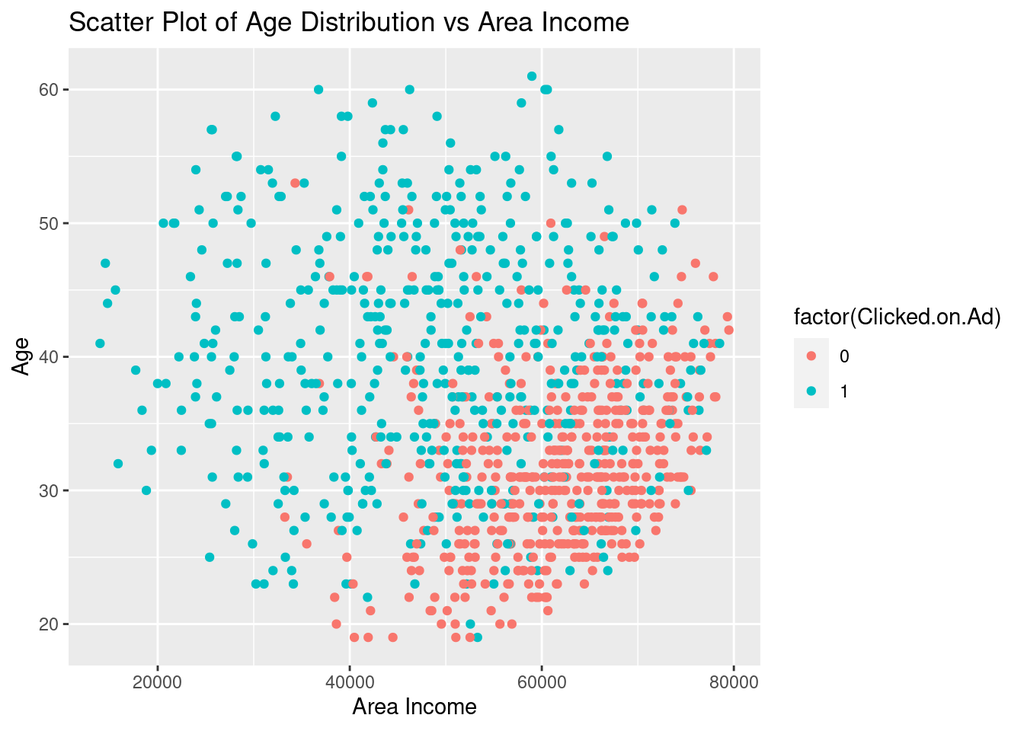

```r
ggplot(advert, aes(Area.Income,Age))+geom_point(aes(colour= factor(`Clicked.on.Ad`)))+
  labs(title = "Scatter Plot of Age Distribution vs Area Income",
       x = "Area Income",
       y = "Age")
```

The scatter plot for the Area Income against Age showed that , majority of the users who did not click on the ad were the high income earners and many of these were aged between 20 and 40 years.

Scatter plot for Income and Daily Internet Usage

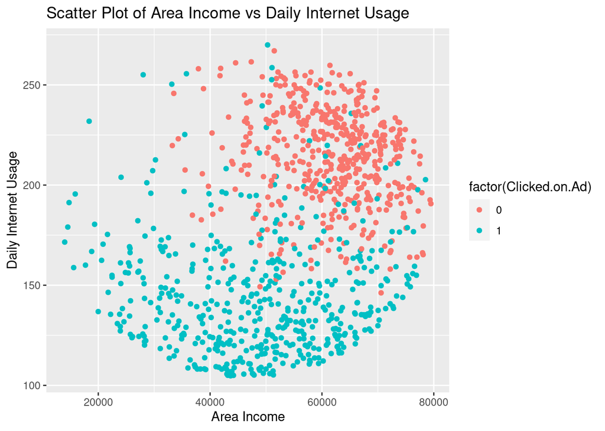

```r
ggplot(advert, aes(Area.Income, Daily.Internet.Usage))+
  geom_point(aes(colour= factor(`Clicked.on.Ad`)))+
  labs(title = "Scatter Plot of Area Income vs Daily Internet Usage",
       x = "Area Income",
       y = "Daily Internet Usage")
```

Scatter Plot of Age Distribution vs Time Spent on Site

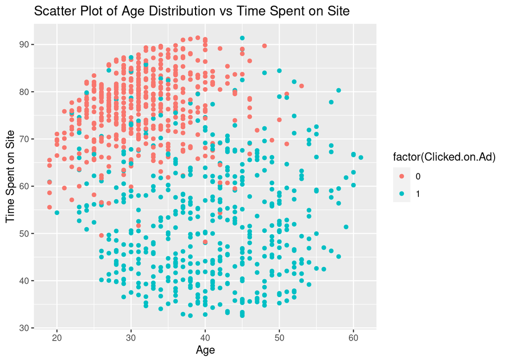

```r
ggplot(advert, aes(Age, Daily.Time.Spent.on.Site))+
  geom_point(aes(colour= factor(`Clicked.on.Ad`)))+
  labs(title = "Scatter Plot of Age Distribution vs Time Spent on Site",
       x = "Age",
       y = "Time Spent on Site")
```

Plotting the Age against Time spent on the site variable we see that the younger demographic are less tolerant to ads despite spending significant amounts of time on the site .

The reason for this may be that younger people , are more tech savvy and therefore are more likely to detect ads and avoid them while using the internet compared to their older counterparts.

Scatter plot for Income Distribution and Daily time spent on site.

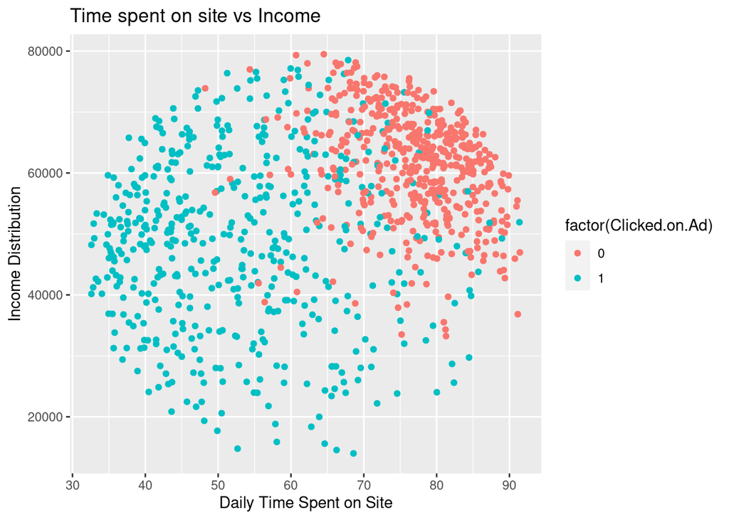

```r
ggplot(advert, aes(Daily.Time.Spent.on.Site, Area.Income))+
  geom_point(aes(colour= factor(`Clicked.on.Ad`)))+
  labs(title = "Time spent on site vs Income",
       x = "Daily Time Spent on Site",
       y = "Income Distribution")
```

The people who were least likely to click on the ad were the higher income earners , this was despite the fact that they seemed to spend a over an hour a day on the site.

The same sentiments can be echoed for the Usage , total internet usage per day, variable . When plotted against income we see that those who spend over 200 minutes online all day and earn more than 50,000 are the least likely to click on ads on the internet.

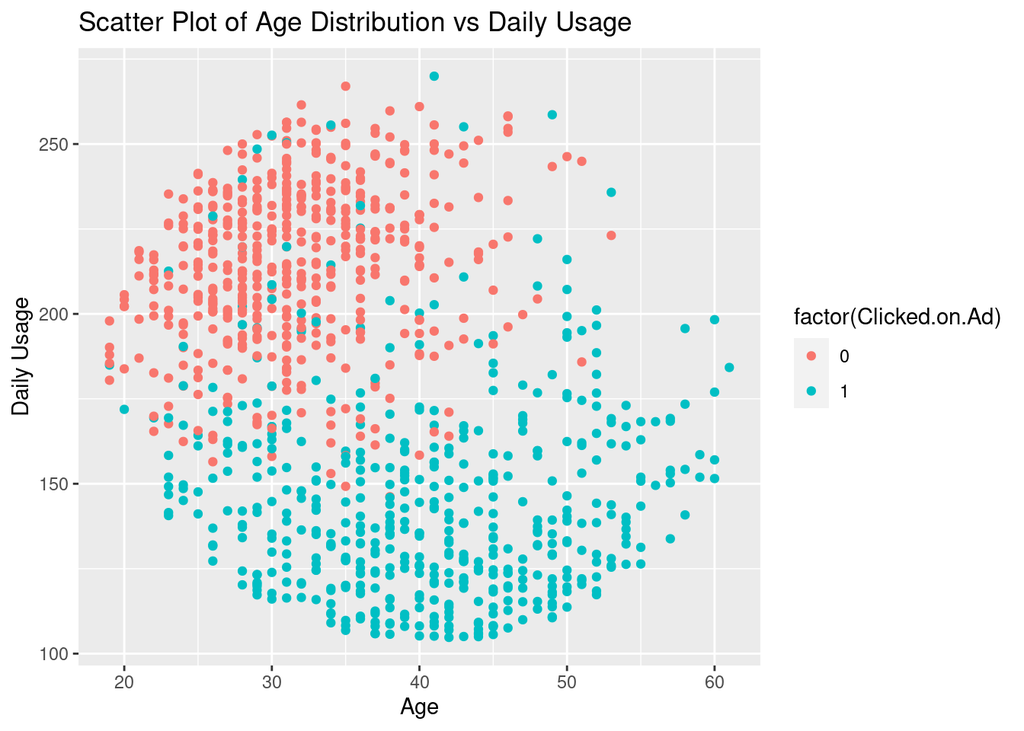

```r
ggplot(advert, aes(Age, Daily.Internet.Usage))+
  geom_point(aes(colour= factor(`Clicked.on.Ad`)))+
  labs(title = "Scatter Plot of Age Distribution vs Daily Usage",
       x = "Age",
       y = "Daily Usage")
```

## Conclusion and Recommendations

- In analyzing this data it was deduced that:
  - Older people , those over 35 were more likely to click on the course ad.
  - The individuals earning higher salaries were more likely not to click on the ad.
  - The probability that a consumer would click on the ad was 0.5.
  - The more time users spent on the blog , the less likely they were to click on the advertisement.
- Thus given these observations I would recommend that:
1. Focusing more on those earning a lower income i.e less than 60,000 would prove to be more beneficial as these consumers click on ads more.
2. Users who were aged over 35 should be targeted more, as they were more likely to click on the ad.
3. Finally the users who spend less time on the site and on the internet in general would prove a better demographic for the ads.